# A tutorial on Bayesian optimization in R

Step-by-step demonstration of BayesOpt for derivative-free minimization of a noiseless, black-box function

Mikhail Popov https://mpopov.com  
2019-05-19

# Introduction

[Optimization](https://en.wikipedia.org/wiki/Mathematical_optimization) of function $f$ is finding an input value $\mathbf{x}_*$ which minimizes (or maximizes) the output value:

$$\mathbf{x}_* = \underset{\mathbf{x}}{\arg\min}~f(\mathbf{x})$$

In this tutorial we will optimize $f(x) = (6x-2)^2~\text{sin}(12x-4)$(Forrester 2008), which looks like this when $x \in [0, 1]$:

[figure not shown]

The ideal scenario is that $f$ is known, has a closed, analytical form, and is [differentiable](https://en.wikipedia.org/wiki/Differentiable_function) – which would enable us to use [gradient descent](https://en.wikipedia.org/wiki/Gradient_descent)-based algorithms For example, here’s how we might optimize it with Adam(Kingma and Ba 2014) in {torch}(Falbel and Luraschi 2021):

```r
library(torch)

x <- torch_zeros(1, requires_grad = TRUE)
f <- function(x) (6 * x - 2) ^ 2 * torch_sin(12 * x - 4)

optimizer <- optim_adam(x, lr = 0.25)

for (i in 1:50) {
  y <- f(x)
  optimizer$zero_grad()
  y$backward()
  optimizer$step()
}
```

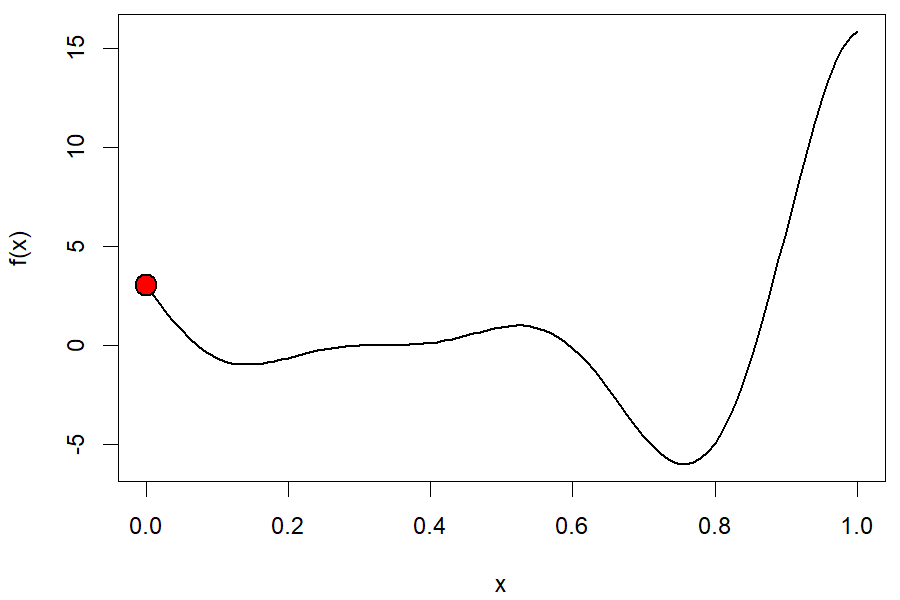

Optimization using Adam in {torch}

But that’s not always the case. Maybe we don’t have a derivative to work with and the evaluation of the function is expensive – hours to train a model or weeks to do an A/B test. [Bayesian optimization](https://en.wikipedia.org/wiki/Bayesian_optimization) (BayesOpt) is one algorithm that helps us perform [derivative-free optimization](https://en.wikipedia.org/wiki/Derivativve-free_optimization) of black-box functions.

# Algorithm

The BayesOpt algorithm for $N$ maximum evaluations can be described using the following pseudocode(Frazier 2018):

```
Place Gaussian process prior on 'f'
Observe 'f' at n0 initial points; set n = n0
while n ≤ N do:
  Update posterior on 'f' using all available data
  Compute acqusition function 'a' using posterior
  Let x* be the value which maximizes 'a'
  Observe f(x*)
  Increment n
end while
Return x for which f(x) was at its best
```

We seed the algorithm with a few initial evaluations and then proceed to sequentially find and evaluate new values, chosen based on some acqusition function, until we’ve exhausted the number of attempts we’re allowed to make.

## Acquisition functions

Let $y_\text{best}$ be the best observed value of $f_n$ (the $n$ evaluations of $f$). How do we choose the next value at which to evaluate $f$? We use an *acquisition function* to guide our choice. There are three major acquisition functions out there, each with its own pros and cons:

1. **Probability of improvement** (least popular): $a_\text{PI}(x)$ measures the probability that a point $x$ will lead to an improvement over $y_\text{best}$
2. **Expected improvement** (most popular): $a_\text{EI}$ incorporates the amount of improvement over $y_\text{best}$
3. **GP lower confidence bound** (newer of the three): $a_\text{LCB}$ (*upper* in case of maximization) balances *exploitation* (points with best expected value) against *exploration* (points with high uncertainty).

In the sections below, each acquisition function will be formally introduced and we’ll see how to implement it in R(R Core Team 2018).

# Implementation

We will use the **GPfit**(MacDonald, Ranjan, and Chipman 2015) package for working with [Gaussian processes](https://en.wikipedia.org/wiki/Gaussian_process).

```r
library(GPfit) # install.packages("GPfit")
```

The algorithm is executed in a loop:

```r
for (iteration in 1:max_iterations) {
  # step 1: fit GP model to evaluated points
  # step 2: calculate utility to find next point
}
```

```r
f <- function(x) {
  return((6 * x - 2)^2 * sin(12 * x - 4))
}
```

We start with $n_0$ equally-spaced points between 0 and 1 on which to evaluate $f$ (without noise) and store these in a matrix `evaluations`:

Initial evaluations

| x | f(x) |
| --- | --- |
| 0.000 | 3.027 |
| 0.333 | 0.000 |
| 0.667 | −3.027 |
| 1.000 | 15.830 |

## GP model fitting

In this example we are going to employ the popular choice of the power exponential correlation function, but the Màtern correlation function `list(type = "matern", nu = 5/2)` may also be used.

sometimes this is called the covariance kernel function

```r
fit <- GP_fit(
  X = evaluations[, "x"],
  Y = evaluations[, "y"],
  corr = list(type = "exponential", power = 1.95)
)
```

Now that we have a fitted GP model, we can calculate the expected value $\mu(x)$ at each possible value of $x$ and the corresponding uncertainty $\sigma(x)$. These will be used when computing the acquisition functions over the possible values of $x$.

```r
x_new <- seq(0, 1, length.out = 100)
pred <- predict.GP(fit, xnew = data.frame(x = x_new))
mu <- pred$Y_hat
sigma <- sqrt(pred$MSE)
```

[figure not shown]

## Calculating utility

As mentioned before, suppose $y_\text{best}$ is the best evaluation we have so far:

```r
y_best <- min(evaluations[, "y"])
```

### Probability of improvement

This utility measures the probability of improving upon $y_\text{best}$, and – since the posterior is Gaussian – we can compute it analytically:

$$a_\text{POI}(x) = \Phi\left(\frac{y_\text{best} - \mu(x)}{\sigma(x)}\right)$$

where $\Phi$ is the standard normal cumulative distribution function. In R, it looks like this:

```r
probability_improvement <- map2_dbl(
  mu,
  sigma,
  function(m, s) {
    if (s == 0) return(0)
    else {
      poi <- pnorm((y_best - m) / s)
      # poi <- 1 - poi (if maximizing)
      return(poi)
    }
  }
)
```

[figure not shown]

Using this acquisition function, the next point which should be evaluated is `x_new[which.max(probability_improvement)]`. After evaluating each new point, we repeat steps 1 and 2 until we have exhausted all tries:

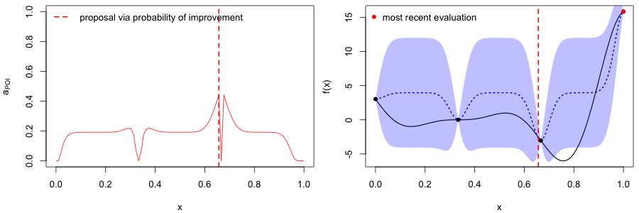

Results after letting BayesOpt choose 4 more points to evaluate via their probability of improvement

### Expected improvement

Let $\gamma(x)$ be the quantity we used in $a_\text{POI}$:

$$\gamma(x) = \frac{y_\text{best} - \mu(x)}{\sigma(x)}$$

Building on probability of improvement, this utility incorporates the amount of improvement:

$$a_\text{EI} = \sigma(x)\left(\gamma(x) \Phi(\gamma(x)) + \mathcal{N}(\gamma(x); 0, 1)\right)$$

In R, it looks like this:

```r
expected_improvement <- map2_dbl(
  mu, sigma,
  function(m, s) {
    if (s == 0) return(0)
    gamma <- (y_best - m) / s
    phi <- pnorm(gamma)
    return(s * (gamma * phi + dnorm(gamma)))
  }
)
```

[figure not shown]

Using this acquisition function, the next point which should be evaluated is `x_new[which.max(expected_improvement)]`. After evaluating each new point, we repeat steps 1 and 2 until we have exhausted all tries:

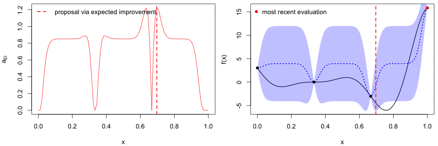

Results after letter BayesOpt choose 4 more points to evaluate via their expected improvement

### GP lower confidence bound

As mentioned above, this utility enables us to control whether the algorithm prefers *exploitation* – picking points which have the best expected values – or *exploration* – picking points which have the highest uncertainty, and this would be more informative to evaluate on. This balance is controlled by a tunable hyperparameter $\kappa$, and in R it looks like:

```r
kappa <- 2 # tunable
lower_confidence_bound <- mu - kappa * sigma
# if maximizing: upper_confidence_bound <- mu + kappa * sigma
```

[figure not shown]

Using this acquisition function, the next point which should be evaluated is `x_new[which.min(lower_confidence_bound)]` (or `x_new[which.max(upper_confidence_bound)]` if maximizing). After evaluating each new point, we repeat steps 1 and 2 until we have exhausted all tries:

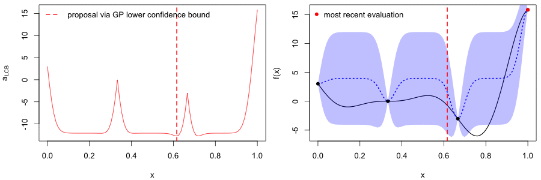

Results after letter BayesOpt choose 4 more points to evaluate via their GP lower confidence bound

# Closing thoughts

This was only a one-dimensional optimization example to show the key ideas and how one might implement them. If you are interested in using this algorithm to tune your models’ parameters, I encourage you to check out [this documentation](http://pyro.ai/examples/bo.html) which describes how to perform Bayesian optimization with [Pyro](http://pyro.ai/) (the probabilistic programming language built on [PyTorch](https://pytorch.org/)); and [pyGPGO](https://pygpgo.readthedocs.io/en/latest/), which is a Bayesian optimization library for Python.

# Further reading

- (Snoek, Larochelle, and Adams 2012) explains how BayesOpt may be used for automatic parameter tuning in machine learning
- (Shahriari et al. 2016) provides a comprehensive review of the algorithm and its applications
- (Chen et al. 2018) shows how DeepMind used BayesOpt to tune AlphaGo during development
- **Gaussian processes**
  - (Görtler, Kehlbeck, and Deussen 2019) is a visual exploration of Gaussian processes
  - (Shi 2019) is GP and covariance matrices
  - (Zhu 2019) is a walkthrough on implementing GP in R and Python
- (Letham et al. 2018) shows how Facebook uses BayesOpt to find next set of parameter values to evaluate with online experiments (A/B tests)

*Update 2019-09-30*: not long after I published this tutorial, Facebook open-sourced PyTorch-based [BoTorch](https://www.botorch.org/) and “adaptive experimentation platform” [Ax](https://ax.dev/). See (Bakshy, Balandat, and Kashin 2019) for more details.

BoTorch uses [GPyTorch](https://gpytorch.ai/) for Gaussian process modeling with GPU support.

# Acknowledgements

You might have noticed a few blue links with “W”s on this page. Those are links to the Wikipedia articles on those topics and if you hover over them, you will see a preview of the article. This is possible with the [ContextCards library](https://chimeces.com/context-cards/) developed by my coworker Joaquin over at Wikimedia, based on the [Popups extension for MediaWiki](https://www.mediawiki.org/wiki/Extension:Popups).

# TensorFlow

*Update 2021-02-28*: I have migrated the part about optimization from [{tensorflow}](https://tensorflow.rstudio.com/) to [{torch}](https://torch.mlverse.org/). For posterity, the (pre-TensorFlow 2.0.0) code was:

```r
library(tensorflow)
sess = tf$Session()

x <- tf$Variable(0.0, trainable = TRUE)
f <- function(x) (6 * x - 2)^2 * tf$sin(12 * x - 4)

adam <- tf$train$AdamOptimizer(learning_rate = 0.3)
opt <- adam$minimize(f(x), var_list = x)

sess$run(tf$global_variables_initializer())

for (i in 1:20) sess$run(opt)
x_best <- sess$run(x)
```

Bakshy, Eytan, Max Balandat, and Kostya Kashin. 2019. “Open-Sourcing Ax and BoTorch: New AI Tools for Adaptive Experimentation.” https://ai.facebook.com/blog/open-sourcing-ax-and-botorch-new-ai-tools-for-adaptive-experimentation/.

Chen, Yutian, Aja Huang, Ziyu Wang, Ioannis Antonoglou, Julian Schrittwieser, David Silver, and Nando de Freitas. 2018. “Bayesian Optimization in AlphaGo.” *arXiv.org*, December. https://arxiv.org/abs/1812.06855.

Falbel, Daniel, and Javier Luraschi. 2021. “Torch: Tensors and Neural Networks with ’GPU’ Acceleration.” https://CRAN.R-project.org/package=torch.

Forrester, Sobester, A. 2008. *Engineering Design via Surrogate Modelling: A Practical Guide*. Wiley.

Frazier, Peter I. 2018. “A Tutorial on Bayesian Optimization.” *arXiv.org*, July. https://arxiv.org/abs/1807.02811.

Görtler, Jochen, Rebecca Kehlbeck, and Oliver Deussen. 2019. “A Visual Exploration of Gaussian Processes.” *Distill*. https://doi.org/10.23915/distill.00017.

Kingma, Diederik P, and Jimmy Ba. 2014. “Adam: A Method for Stochastic Optimization.” *arXiv.org*, December. https://arxiv.org/abs/1412.6980.

Letham, Benjamin, Brian Karrer, Guilherme Ottoni, and Eytan Bakshy. 2018. “Constrained Bayesian Optimization with Noisy Experiments.” *arXiv.org*, August. https://arxiv.org/abs/1706.07094.

MacDonald, Blake, Pritam Ranjan, and Hugh Chipman. 2015. “GPfit: An R Package for Fitting a Gaussian Process Model to Deterministic Simulator Outputs.” *Journal of Statistical Software* 64 (12): 1–23. https://www.jstatsoft.org/v64/i12/.

R Core Team. 2018. *R: A Language and Environment for Statistical Computing*. Vienna, Austria: R Foundation for Statistical Computing. https://www.R-project.org/.

Shahriari, Bobak, Kevin Swersky, Ziyu Wang, Ryan P Adams, and Nando de Freitas. 2016. “Taking the Human Out of the Loop: A Review of Bayesian Optimization.” *Proceedings of the IEEE* 104 (1): 148–75.

Shi, Yuge. 2019. “Gaussian Process, Not Quite for Dummies.” https://yugeten.github.io/posts/2019/09/GP/.

Snoek, Jasper, Hugo Larochelle, and Ryan P Adams. 2012. “Practical Bayesian Optimization of Machine Learning Algorithms,” June. https://arxiv.org/abs/1206.2944.

Zhu, Hao. 2019. “Implementing Gaussian Process in Python and r.” https://zhuhao.org/post/gp_python_r/.